# Homework 7

Quynh Tran

March 20, 2018

### Exercise 1

Train.csv dataset has 24 variables and 1460 observations.

### Exercise 2

```r
library(tidyverse)
library(broom)


file_path <- '~/compscix-415-2-assignments/train.csv'
train <- read_csv(file = file_path)
set.seed(29283)

# When taking a random sample, it is often useful to set a seed so that your work is reproducible. Setting a seed will guarantee that the same random sample will be generated every time, so long as you always set the # same seed beforehand.

train_set <- train %>% sample_frac(.70) # Let's create our training set using sample_frac. Fill in the blank.
```

```r
test_set <- train %>% filter(!(train$Id %in% train_set$Id))
#This data already has an Id column which we can make use of. let's create our testing set using the Id column. Fill in the blanks.
```

### Exercise 3

Our target is called SalePrice. First, we can fit a simple regression model consisting of only the intercept (the average of SalePrice). Fit the model and then use the broom package to • take a look at the coefficient, • compare the coefficient to the average value of SalePrice, and take a look at the R-squared.

#### The y-intercept is $182,176, which is the same as the mean SalePrice. The R-square is 0.

```r
# Fit a model with intercept only
(mod_0 <- lm(SalePrice ~ 1, data =train_set))
```

```
##
## Call:
## lm(formula = SalePrice ~ 1, data = train_set)
##
## Coefficients:
## (Intercept)
##      182176
```

```r
# Double-check that the average SalePrice is equal to our model's coefficient
mean(train_set$SalePrice)
```

```
## [1] 182176
```

```r
tidy(mod_0)
```

```
##          term estimate std.error statistic p.value
## 1 (Intercept)   182176  2492.072  73.10222       0
```

```r
glance(mod_0)
```

```
##   r.squared adj.r.squared    sigma statistic p.value df    logLik      AIC
## 1         0             0 79668.37        NA      NA  1 -12983.57 25971.13
##        BIC     deviance df.residual
## 1 25980.99 6.480338e+12        1021
```

### Exercise 4

Now fit a linear regression model using GrLivArea, OverallQual, and Neighborhood as the features. Don’t forget to look at data_description.txt to understand what these variables mean. Ask yourself these questions before fitting the model:

What kind of relationship will these features have with our target? Can the relationship be estimated linearly?

#### GrLivArea is the living area square feet; OverallQual is a rating 1-10 of the material/finish of the house; Neighborhood is a categorical variable naming physical locations in Ames, Iowa. I expect positive relationship between the living area square footage and overall quality with the sales price of the home. I do not know anything about the neighborhood characteristics so cannot make a prediction.

```r
(model_LivArea <- lm(formula=SalePrice ~ GrLivArea, data =train_set))
```

```
##
## Call:
## lm(formula = SalePrice ~ GrLivArea, data = train_set)
##
## Coefficients:
## (Intercept)    GrLivArea
##      7518.6        115.8
```

```r
tidy (model_LivArea)
```

```
##          term estimate   std.error statistic       p.value
## 1 (Intercept) 7518.567 5334.586903   1.40940  1.590217e-01
## 2   GrLivArea  115.833    3.354991  34.52558 1.189915e-173
```

```r
glance (model_LivArea)
```

```
##   r.squared adj.r.squared    sigma statistic       p.value df logLik   AIC
## 1 0.5388821     0.5384301 54125.85  1192.016 1.189915e-173  2 -12588 25182
##        BIC   deviance df.residual
## 1 25196.79 2.9882e+12        1020
```

```r
(model_OverQual <- lm(formula=SalePrice ~ OverallQual, data =train_set))
```

```
##
## Call:
## lm(formula = SalePrice ~ OverallQual, data = train_set)
##
## Coefficients:
## (Intercept)  OverallQual
##     -105873        47192
```

```r
tidy (model_OverQual)
```

```
##          term  estimate std.error statistic       p.value
## 1 (Intercept) -105872.5  6893.466 -15.35839  4.801210e-48
## 2 OverallQual   47192.3  1102.649  42.79902 5.918164e-230
```

```r
glance (model_OverQual)
```

```
##   r.squared adj.r.squared    sigma statistic       p.value df    logLik
## 1 0.6423257      0.641975 47669.72  1831.756 5.918164e-230  2 -12458.19
##        AIC      BIC     deviance df.residual
## 1 24922.38 24937.17 2.317851e+12        1020
```

```r
(model_Neighb <- lm(formula=SalePrice ~ Neighborhood, data =train_set))
```

```
##
## Call:
## lm(formula = SalePrice ~ Neighborhood, data = train_set)
##
## Coefficients:
##         (Intercept)  NeighborhoodBlueste   NeighborhoodBrDale
##              200308               -76308               -92908
## NeighborhoodBrkSide  NeighborhoodClearCr  NeighborhoodCollgCr
##              -76713                19854                -4492
## NeighborhoodCrawfor  NeighborhoodEdwards  NeighborhoodGilbert
##                4905               -69405                -9248
##  NeighborhoodIDOTRR  NeighborhoodMeadowV  NeighborhoodMitchel
##              -94072              -103085               -44658
##   NeighborhoodNAmes  NeighborhoodNoRidge  NeighborhoodNPkVill
##              -54161               135254               -59058
## NeighborhoodNridgHt   NeighborhoodNWAmes  NeighborhoodOldTown
##              118035               -12272               -72381
##  NeighborhoodSawyer  NeighborhoodSawyerW  NeighborhoodSomerst
##              -63193               -20426                34566
## NeighborhoodStoneBr    NeighborhoodSWISU   NeighborhoodTimber
##              118544               -52975                52346
## NeighborhoodVeenker
##               63620
```

```r
tidy (model_Neighb)
```

```
##                   term    estimate std.error  statistic      p.value
## 1          (Intercept)  200308.462  14880.25 13.4613631 4.487217e-38
## 2  NeighborhoodBlueste  -76308.462  55676.80 -1.3705612 1.708203e-01
## 3   NeighborhoodBrDale  -92908.462  21979.59 -4.2270339 2.585277e-05
## 4  NeighborhoodBrkSide  -76713.249  16812.68 -4.5628209 5.675519e-06
## 5  NeighborhoodClearCr   19853.672  20330.29  0.9765561 3.290259e-01
## 6  NeighborhoodCollgCr   -4491.700  15774.54 -0.2847437 7.758997e-01
## 7  NeighborhoodCrawfor    4905.221  17077.14  0.2872390 7.739890e-01
## 8  NeighborhoodEdwards  -69405.077  16300.50 -4.2578500 2.259005e-05
## 9  NeighborhoodGilbert   -9247.988  16490.05 -0.5608225 5.750446e-01
## 10  NeighborhoodIDOTRR  -94072.098  18768.65 -5.0121942 6.365074e-07
## 11 NeighborhoodMeadowV -103085.385  21043.85 -4.8985984 1.125722e-06
## 12 NeighborhoodMitchel  -44658.462  17727.84 -2.5191151 1.192047e-02
## 13   NeighborhoodNAmes  -54161.231  15455.33 -3.5043723 4.780249e-04
## 14 NeighborhoodNoRidge  135254.147  18616.48  7.2652908 7.499696e-13
## 15 NeighborhoodNPkVill  -59058.462  25152.21 -2.3480422 1.906702e-02
## 16 NeighborhoodNridgHt  118035.386  16438.06  7.1806164 1.355530e-12
## 17  NeighborhoodNWAmes  -12271.923  16636.63 -0.7376449 4.609038e-01
## 18 NeighborhoodOldTown  -72380.651  16134.44 -4.4860949 8.097746e-06
## 19  NeighborhoodSawyer  -63192.622  16703.04 -3.7833005 1.639801e-04
## 20 NeighborhoodSawyerW  -20425.787  16981.27 -1.2028425 2.293228e-01
## 21 NeighborhoodSomerst   34565.772  16413.31  2.1059604 3.545731e-02
## 22 NeighborhoodStoneBr  118543.907  19311.16  6.1386206 1.199918e-09
## 23   NeighborhoodSWISU  -52975.087  20033.15 -2.6443711 8.312879e-03
## 24  NeighborhoodTimber   52345.885  18224.51  2.8722792 4.161598e-03
## 25 NeighborhoodVeenker   63620.110  25152.21  2.5294039 1.157881e-02
```

```r
glance(model_Neighb)
```

```
##   r.squared adj.r.squared    sigma statistic       p.value df    logLik
## 1 0.5571452     0.5464847 53651.51  52.26259 1.011167e-157 25 -12567.35
##       AIC      BIC     deviance df.residual
## 1 25186.7 25314.87 2.869849e+12         997
```

```r
train_set <- train_set %>% mutate(neigh_fct = factor(Neighborhood, ordered = FALSE))
(model_Neighb <- lm(formula=SalePrice ~ neigh_fct, data =train_set))
```

```
##
## Call:
## lm(formula = SalePrice ~ neigh_fct, data = train_set)
##
## Coefficients:
##      (Intercept)  neigh_fctBlueste   neigh_fctBrDale  neigh_fctBrkSide
##           200308            -76308            -92908            -76713
## neigh_fctClearCr  neigh_fctCollgCr  neigh_fctCrawfor  neigh_fctEdwards
##            19854             -4492              4905            -69405
## neigh_fctGilbert   neigh_fctIDOTRR  neigh_fctMeadowV  neigh_fctMitchel
##            -9248            -94072           -103085            -44658
##   neigh_fctNAmes  neigh_fctNoRidge  neigh_fctNPkVill  neigh_fctNridgHt
##           -54161            135254            -59058            118035
##  neigh_fctNWAmes  neigh_fctOldTown   neigh_fctSawyer  neigh_fctSawyerW
##           -12272            -72381            -63193            -20426
## neigh_fctSomerst  neigh_fctStoneBr    neigh_fctSWISU   neigh_fctTimber
##            34566            118544            -52975             52346
## neigh_fctVeenker
##            63620
```

```r
(multmodel_1 <- lm(formula=SalePrice ~ GrLivArea + OverallQual + Neighborhood, data =train_set))
```

```
##
## Call:
## lm(formula = SalePrice ~ GrLivArea + OverallQual + Neighborhood,
##     data = train_set)
##
## Coefficients:
##         (Intercept)            GrLivArea          OverallQual
##           -45017.87                62.78             21692.23
## NeighborhoodBlueste   NeighborhoodBrDale  NeighborhoodBrkSide
##           -38288.88            -43314.05            -14064.37
## NeighborhoodClearCr  NeighborhoodCollgCr  NeighborhoodCrawfor
##            27839.01              4297.67              7423.06
## NeighborhoodEdwards  NeighborhoodGilbert   NeighborhoodIDOTRR
##           -15284.11             -8357.56            -32689.43
## NeighborhoodMeadowV  NeighborhoodMitchel    NeighborhoodNAmes
##           -14446.07              1922.31             -7719.68
## NeighborhoodNoRidge  NeighborhoodNPkVill  NeighborhoodNridgHt
##            47685.17            -20240.71             63872.81
##  NeighborhoodNWAmes  NeighborhoodOldTown   NeighborhoodSawyer
##           -12279.33            -36107.08             -4121.93
## NeighborhoodSawyerW  NeighborhoodSomerst  NeighborhoodStoneBr
##            -5391.97             18700.97             65712.46
##   NeighborhoodSWISU   NeighborhoodTimber  NeighborhoodVeenker
##           -45451.87             27925.09             54913.13
```

```r
tidy(multmodel_1)
```

```
##                   term     estimate    std.error  statistic      p.value
## 1          (Intercept) -45017.87483 12933.341808 -3.4807612 5.216927e-04
## 2            GrLivArea     62.77735     3.006033 20.8837885 1.337222e-80
## 3          OverallQual  21692.23178  1353.714104 16.0242342 1.389020e-51
## 4  NeighborhoodBlueste -38288.88063 36531.907177 -1.0480942 2.948497e-01
## 5   NeighborhoodBrDale -43314.05372 14524.693991 -2.9820975 2.932566e-03
## 6  NeighborhoodBrkSide -14064.37052 11318.850018 -1.2425618 2.143221e-01
## 7  NeighborhoodClearCr  27839.00662 13561.346871  2.0528202 4.035110e-02
## 8  NeighborhoodCollgCr   4297.67432 10372.304467  0.4143413 6.787135e-01
## 9  NeighborhoodCrawfor   7423.05573 11371.511784  0.6527765 5.140512e-01
## 10 NeighborhoodEdwards -15284.11495 10994.287187 -1.3901870 1.647830e-01
## 11 NeighborhoodGilbert  -8357.55930 10894.173472 -0.7671586 4.431692e-01
## 12  NeighborhoodIDOTRR -32689.43085 12603.712743 -2.5936350 9.636216e-03
## 13 NeighborhoodMeadowV -14446.06504 14190.148622 -1.0180348 3.089089e-01
## 14 NeighborhoodMitchel   1922.31487 11788.608170  0.1630655 8.705000e-01
## 15   NeighborhoodNAmes  -7719.67883 10375.956174 -0.7439969 4.570540e-01
## 16 NeighborhoodNoRidge  47685.16790 12567.432633  3.7943444 1.569690e-04
## 17 NeighborhoodNPkVill -20240.71145 16548.664867 -1.2231024 2.215806e-01
## 18 NeighborhoodNridgHt  63872.80848 10880.456671  5.8704161 5.917964e-09
## 19  NeighborhoodNWAmes -12279.33299 11047.502893 -1.1115030 2.666204e-01
## 20 NeighborhoodOldTown -36107.07577 10849.170903 -3.3280954 9.064637e-04
## 21  NeighborhoodSawyer  -4121.92502 11252.369778 -0.3663162 7.142070e-01
## 22 NeighborhoodSawyerW  -5391.97074 11230.758221 -0.4801075 6.312565e-01
## 23 NeighborhoodSomerst  18700.96725 10772.212794  1.7360377 8.286672e-02
## 24 NeighborhoodStoneBr  65712.45881 12745.312907  5.1558137 3.045915e-07
## 25   NeighborhoodSWISU -45451.86707 13564.792586 -3.3507233 8.363074e-04
## 26  NeighborhoodTimber  27925.08619 11985.325857  2.3299397 2.000859e-02
## 27 NeighborhoodVeenker  54913.12768 16521.075497  3.3238228 9.203087e-04
```

```r
glance(multmodel_1)
```

```
##   r.squared adj.r.squared   sigma statistic p.value df    logLik      AIC
## 1 0.8099927     0.8050277 35178.1  163.1401       0 27 -12134.95 24325.91
##        BIC     deviance df.residual
## 1 24463.93 1.231311e+12         995
```

```r
(multmodel_2 <- lm(formula=SalePrice ~ GrLivArea + OverallQual + neigh_fct, data =train_set))
```

```
##
## Call:
## lm(formula = SalePrice ~ GrLivArea + OverallQual + neigh_fct,
##     data = train_set)
##
## Coefficients:
##      (Intercept)         GrLivArea       OverallQual  neigh_fctBlueste
##        -45017.87             62.78          21692.23         -38288.88
##  neigh_fctBrDale  neigh_fctBrkSide  neigh_fctClearCr  neigh_fctCollgCr
##        -43314.05         -14064.37          27839.01           4297.67
## neigh_fctCrawfor  neigh_fctEdwards  neigh_fctGilbert   neigh_fctIDOTRR
##          7423.06         -15284.11          -8357.56         -32689.43
## neigh_fctMeadowV  neigh_fctMitchel    neigh_fctNAmes  neigh_fctNoRidge
##        -14446.07           1922.31          -7719.68          47685.17
## neigh_fctNPkVill  neigh_fctNridgHt   neigh_fctNWAmes  neigh_fctOldTown
##        -20240.71          63872.81         -12279.33         -36107.08
##  neigh_fctSawyer  neigh_fctSawyerW  neigh_fctSomerst  neigh_fctStoneBr
##         -4121.93          -5391.97          18700.97          65712.46
##   neigh_fctSWISU   neigh_fctTimber  neigh_fctVeenker
##        -45451.87          27925.09          54913.13
```

```r
tidy(multmodel_2)
```

```
##                term     estimate    std.error  statistic      p.value
## 1       (Intercept) -45017.87483 12933.341808 -3.4807612 5.216927e-04
## 2         GrLivArea     62.77735     3.006033 20.8837885 1.337222e-80
## 3       OverallQual  21692.23178  1353.714104 16.0242342 1.389020e-51
## 4  neigh_fctBlueste -38288.88063 36531.907177 -1.0480942 2.948497e-01
## 5   neigh_fctBrDale -43314.05372 14524.693991 -2.9820975 2.932566e-03
## 6  neigh_fctBrkSide -14064.37052 11318.850018 -1.2425618 2.143221e-01
## 7  neigh_fctClearCr  27839.00662 13561.346871  2.0528202 4.035110e-02
## 8  neigh_fctCollgCr   4297.67432 10372.304467  0.4143413 6.787135e-01
## 9  neigh_fctCrawfor   7423.05573 11371.511784  0.6527765 5.140512e-01
## 10 neigh_fctEdwards -15284.11495 10994.287187 -1.3901870 1.647830e-01
## 11 neigh_fctGilbert  -8357.55930 10894.173472 -0.7671586 4.431692e-01
## 12  neigh_fctIDOTRR -32689.43085 12603.712743 -2.5936350 9.636216e-03
## 13 neigh_fctMeadowV -14446.06504 14190.148622 -1.0180348 3.089089e-01
## 14 neigh_fctMitchel   1922.31487 11788.608170  0.1630655 8.705000e-01
## 15   neigh_fctNAmes  -7719.67883 10375.956174 -0.7439969 4.570540e-01
## 16 neigh_fctNoRidge  47685.16790 12567.432633  3.7943444 1.569690e-04
## 17 neigh_fctNPkVill -20240.71145 16548.664867 -1.2231024 2.215806e-01
## 18 neigh_fctNridgHt  63872.80848 10880.456671  5.8704161 5.917964e-09
## 19  neigh_fctNWAmes -12279.33299 11047.502893 -1.1115030 2.666204e-01
## 20 neigh_fctOldTown -36107.07577 10849.170903 -3.3280954 9.064637e-04
## 21  neigh_fctSawyer  -4121.92502 11252.369778 -0.3663162 7.142070e-01
## 22 neigh_fctSawyerW  -5391.97074 11230.758221 -0.4801075 6.312565e-01
## 23 neigh_fctSomerst  18700.96725 10772.212794  1.7360377 8.286672e-02
## 24 neigh_fctStoneBr  65712.45881 12745.312907  5.1558137 3.045915e-07
## 25   neigh_fctSWISU -45451.86707 13564.792586 -3.3507233 8.363074e-04
## 26  neigh_fctTimber  27925.08619 11985.325857  2.3299397 2.000859e-02
## 27 neigh_fctVeenker  54913.12768 16521.075497  3.3238228 9.203087e-04
```

```r
glance(multmodel_2)
```

```
##   r.squared adj.r.squared   sigma statistic p.value df    logLik      AIC
## 1 0.8099927     0.8050277 35178.1  163.1401       0 27 -12134.95 24325.91
##        BIC     deviance df.residual
## 1 24463.93 1.231311e+12         995
```

Are these good features, given the problem we are trying to solve? After fitting the model, output the coefficients and the R-squared using the broom package. Answer these questions: How would you interpret the coefficients on GrLivArea and OverallQual?

Coefficients: (Intercept) GrLivArea  
7518.6 115.8

#### For every one square foot GrLivArea increase, SalesPrice on average increases by 115.80 dollars Theoretically if house has 0 square feet, it would cost $7518.60.

(Intercept) OverallQual  
-105873 47192

#### For every one unit increase in OverallQual (ranging from 1-10), there is an increase on average by $47,192. Theoretically if the house has a zero rating on OverallQual, it would cost -105,873.

Coefficients: (Intercept) GrLivArea OverallQual NeighborhoodBlueste  
-45017.87 62.78 21692.23 -38288.88  
NeighborhoodBrDale NeighborhoodBrkSide NeighborhoodClearCr NeighborhoodCollgCr  
-43314.05 -14064.37 27839.01 4297.67  
NeighborhoodCrawfor NeighborhoodEdwards NeighborhoodGilbert NeighborhoodIDOTRR  
7423.06 -15284.11 -8357.56 -32689.43  
NeighborhoodMeadowV NeighborhoodMitchel NeighborhoodNAmes NeighborhoodNoRidge  
-14446.07 1922.31 -7719.68 47685.17  
NeighborhoodNPkVill NeighborhoodNridgHt NeighborhoodNWAmes NeighborhoodOldTown  
-20240.71 63872.81 -12279.33 -36107.08  
NeighborhoodSawyer NeighborhoodSawyerW NeighborhoodSomerst NeighborhoodStoneBr  
-4121.93 -5391.97 18700.97 65712.46  
NeighborhoodSWISU NeighborhoodTimber NeighborhoodVeenker  
-45451.87 27925.09 54913.13

#### In the multivariate model, for every one square foot increase in GrLivArea and one level increase in OverallQual, the price increases by $62.77 and 21,692 dollars, on average.

• How would you interpret the coefficient on NeighborhoodBrkSide? Coefficients: (Intercept) neigh_fctBlueste neigh_fctBrDale neigh_fctBrkSide neigh_fctClearCr  
200308 -76308 -92908 -76713 19854  
neigh_fctCollgCr neigh_fctCrawfor neigh_fctEdwards neigh_fctGilbert neigh_fctIDOTRR  
-4492 4905 -69405 -9248 -94072  
neigh_fctMeadowV neigh_fctMitchel neigh_fctNAmes neigh_fctNoRidge neigh_fctNPkVill  
-103085 -44658 -54161 135254 -59058  
neigh_fctNridgHt neigh_fctNWAmes neigh_fctOldTown neigh_fctSawyer neigh_fctSawyerW  
118035 -12272 -72381 -63193 -20426  
neigh_fctSomerst neigh_fctStoneBr neigh_fctSWISU neigh_fctTimber neigh_fctVeenker  
34566 118544 -52975 52346 63620

#### The neighborhoods with positive coefficients (compared to BloomingtonHeights) are: ClearCr, Crawfor, NoRidge, NridgHt, Somerst, StoneBr, Timber, Veenker. NeighborhoodNoRidge has the strongest effect, with an average increase of $135,254.14 for homes in this neigborhood compared to BloomingtonHeights.

#### The neighborhoods with negative coefficients are: Blueste, BrDale, BrkSide, CollgCr, Edwards, Gilbert, IDOTRR, MeadowV, Mitchel, NAmes, NPkVill, NWAmes, OldTown, Sawyer, SawyerW, SWISU. Neighborhood MeadowV has the strongest negative effect, with an average decrease of $103,085 for homes in this neighborhood compared to BloomingtonHeights.

#### If neighborhoods are the only predictor of SalePrice, Neighborhood BrkSide has a negative effect of $76,713 on average for homes compared to BloomingtonHeights.

#### In the multivariate model, Neighborhood BrkSide has a negative effect of $14,064.37 on average for homes compared to BloomingtonHeights.

• Are the features significant?

• Are the features practically significant?

#### All the features are practically significant.

• Is the model a good fit (to the training set)?

#### Yes. The r-squared is the proportion of variability in Y explained by the model. Its p-value for the linear regression model as well as multi-variate regression model shows that the models are a good fit. All their p-values are less than 0.05.

### Exercise 5

Evaluate the model on test_set using the root mean squared error (RMSE). Use the predict function to get the model predictions for the testing set. Hint: use the sqrt() and mean() functions:

```r
test_predictions <- predict(multmodel_1, newdata = test_set)

rmse <- sqrt(mean((test_set$SalePrice-test_predictions)^2))
rmse
```

```
## [1] 41915.27
```

### Exercise 6 (OPTIONAL - won’t be graded)

Feel free to play around with linear regression. Add some other features and see how the model results change. Test the model on test_set to compare the RMSE’s.

```r
(Sales_model <- lm(formula=SalePrice ~ GrLivArea + OverallQual + OverallCond+ LotArea+ Neighborhood + BldgType + Condition1, data =train_set))
```

```
##
## Call:
## lm(formula = SalePrice ~ GrLivArea + OverallQual + OverallCond +
##     LotArea + Neighborhood + BldgType + Condition1, data = train_set)
##
## Coefficients:
##         (Intercept)            GrLivArea          OverallQual
##          -4.513e+04            5.989e+01            2.033e+04
##         OverallCond              LotArea  NeighborhoodBlueste
##           4.426e+03            6.859e-01           -4.342e+04
##  NeighborhoodBrDale  NeighborhoodBrkSide  NeighborhoodClearCr
##          -3.106e+04           -5.251e+04           -2.699e+04
## NeighborhoodCollgCr  NeighborhoodCrawfor  NeighborhoodEdwards
##          -2.783e+04           -3.167e+04           -4.828e+04
## NeighborhoodGilbert   NeighborhoodIDOTRR  NeighborhoodMeadowV
##          -4.278e+04           -6.891e+04           -1.383e+04
## NeighborhoodMitchel    NeighborhoodNAmes  NeighborhoodNoRidge
##          -3.031e+04           -4.348e+04            1.641e+04
## NeighborhoodNPkVill  NeighborhoodNridgHt   NeighborhoodNWAmes
##          -1.863e+04            4.311e+04           -5.034e+04
## NeighborhoodOldTown   NeighborhoodSawyer  NeighborhoodSawyerW
##          -6.984e+04           -3.906e+04           -3.240e+04
## NeighborhoodSomerst  NeighborhoodStoneBr    NeighborhoodSWISU
##          -1.933e+03            4.645e+04           -7.883e+04
##  NeighborhoodTimber  NeighborhoodVeenker       BldgType2fmCon
##          -1.557e+04            2.145e+04           -9.376e+03
##      BldgTypeDuplex        BldgTypeTwnhs       BldgTypeTwnhsE
##          -2.196e+04           -5.108e+04           -2.857e+04
##     Condition1Feedr       Condition1Norm       Condition1PosA
##           8.514e+03            1.811e+04            1.938e+04
##      Condition1PosN       Condition1RRAe       Condition1RRAn
##           2.302e+04            4.630e+03            1.637e+04
##      Condition1RRNe       Condition1RRNn
##          -1.218e+04            1.015e+04
```

```r
tidy(Sales_model)
```

```
##                   term      estimate    std.error  statistic      p.value
## 1          (Intercept) -4.513171e+04 1.564678e+04 -2.8844085 4.007283e-03
## 2            GrLivArea  5.989492e+01 3.021851e+00 19.8206051 8.514807e-74
## 3          OverallQual  2.032762e+04 1.313424e+03 15.4768237 1.656015e-48
## 4          OverallCond  4.425722e+03 1.070287e+03  4.1350813 3.851983e-05
## 5              LotArea  6.858692e-01 1.060504e-01  6.4673908 1.570386e-10
## 6  NeighborhoodBlueste -4.342480e+04 3.400142e+04 -1.2771466 2.018527e-01
## 7   NeighborhoodBrDale -3.105888e+04 1.470016e+04 -2.1128260 3.486777e-02
## 8  NeighborhoodBrkSide -5.251351e+04 1.178849e+04 -4.4546436 9.369609e-06
## 9  NeighborhoodClearCr -2.699415e+04 1.386277e+04 -1.9472416 5.179083e-02
## 10 NeighborhoodCollgCr -2.783439e+04 1.065503e+04 -2.6123242 9.130361e-03
## 11 NeighborhoodCrawfor -3.167127e+04 1.159983e+04 -2.7303210 6.440648e-03
## 12 NeighborhoodEdwards -4.828131e+04 1.124027e+04 -4.2953868 1.917338e-05
## 13 NeighborhoodGilbert -4.277928e+04 1.121953e+04 -3.8129287 1.458993e-04
## 14  NeighborhoodIDOTRR -6.890927e+04 1.276528e+04 -5.3981781 8.444651e-08
```

[output cut: 27 more lines]

```r
glance(Sales_model)
```

```
##   r.squared adj.r.squared    sigma statistic p.value df    logLik      AIC
## 1 0.8379472     0.8313395 32718.44  126.8146       0 41 -12053.63 24191.26
##       BIC     deviance df.residual
## 1 24398.3 1.050157e+12         981
```

### Exercise 7

One downside of the linear model is that it is sensitive to unusual values because the distance incorporates a squared term. Fit a linear model to the simulated data below, and visualise the results. Rerun a few times to generate different simulated datasets. What do you notice about the model?

```r
sim1a <- tibble(
x = rep(1:10, each = 3),
y = x * 1.5 + 6 + rt(length(x), df = 2))

uni_mod1 <- lm(y~x, data=sim1a)
tidy(uni_mod1)
```

```
##          term estimate std.error statistic      p.value
## 1 (Intercept) 6.694060 0.8711790  7.683909 2.270460e-08
## 2           x 1.456668 0.1404032 10.374889 4.244805e-11
```

```r
glance(uni_mod1)
```

```
##   r.squared adj.r.squared    sigma statistic      p.value df    logLik
## 1 0.7935687     0.7861961 2.208842  107.6383 4.244805e-11  2 -65.30731
##        AIC      BIC deviance df.residual
## 1 136.6146 140.8182 136.6115          28
```

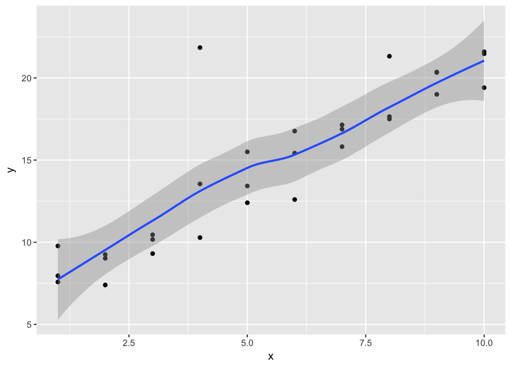

```r
ggplot (data=sim1a, aes(x=x, y=y)) +
  geom_point() + geom_smooth()
```

```r
sim2a <- tibble(
x = rep(1:10, each = 3),
y = x * 1.5 + 6 + rt(length(x), df = 2))

uni_mod2 <- lm(y~x, data=sim2a)
tidy(uni_mod2)
```

```
##          term estimate std.error statistic      p.value
## 1 (Intercept) 5.246398 0.8619100  6.086944 1.448825e-06
## 2           x 1.539638 0.1389094 11.083761 9.471390e-12
```

```r
glance(uni_mod2)
```

```
##   r.squared adj.r.squared    sigma statistic     p.value df    logLik
## 1 0.8143849     0.8077557 2.185341  122.8498 9.47139e-12  2 -64.98642
##        AIC      BIC deviance df.residual
## 1 135.9728 140.1764   133.72          28
```

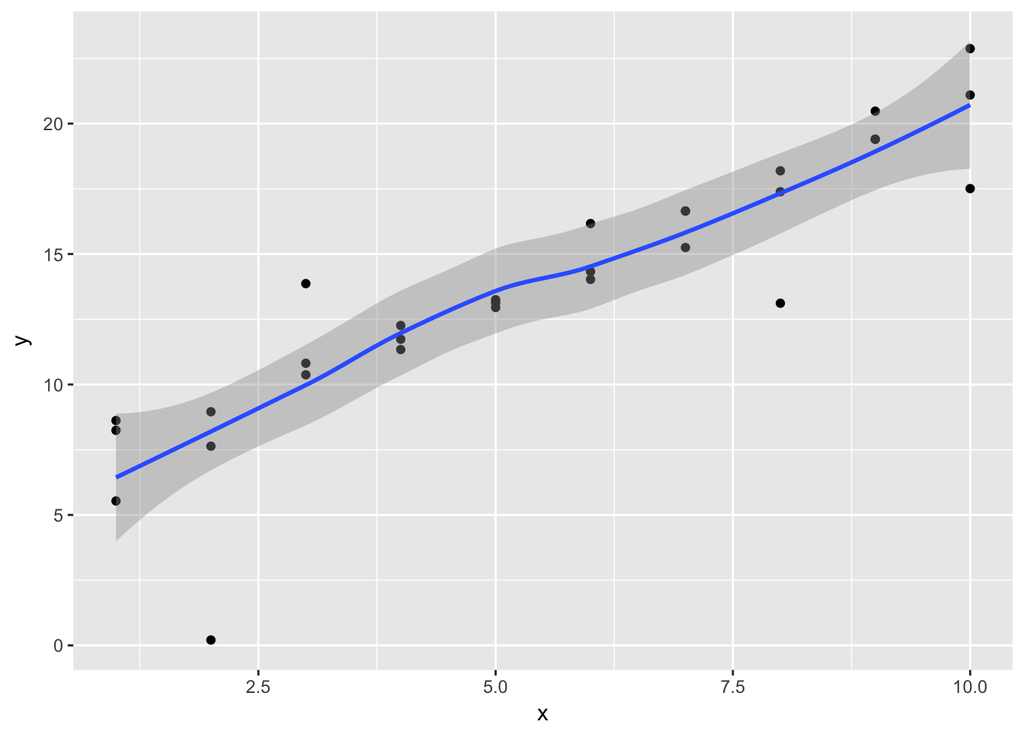

```r
ggplot (data=sim2a, aes(x=x, y=y)) +
  geom_point()+ geom_smooth()
```

```r
sim3a <- tibble(
x = rep(1:10, each = 3),
y = x * 1.5 + 6 + rt(length(x), df = 2))


uni_mod3 <- lm(y~x, data=sim3a)
tidy(uni_mod3)
```

```
##          term estimate std.error statistic      p.value
## 1 (Intercept) 6.288157 0.7594053   8.28037 5.198442e-09
## 2           x 1.373230 0.1223892  11.22019 7.146453e-12
```

```r
glance(uni_mod3)
```

```
##   r.squared adj.r.squared    sigma statistic      p.value df    logLik
## 1 0.8180549     0.8115569 1.925444  125.8926 7.146453e-12  2 -61.18796
##        AIC      BIC deviance df.residual
## 1 128.3759 132.5795 103.8054          28
```

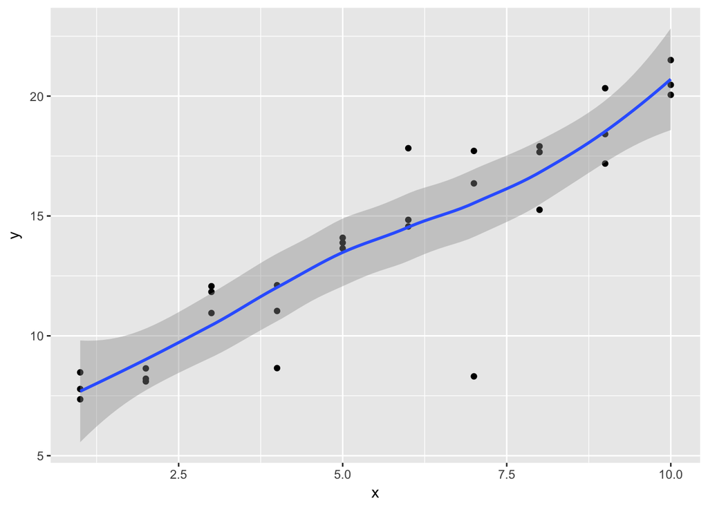

```r
ggplot (data=sim3a, aes(x=x, y=y)) +
  geom_point()+ geom_smooth()
```

```r
sim4a <- tibble(
x = rep(1:10, each = 3),
y = x * 1.5 + 6 + rt(length(x), df = 2))

uni_mod4 <- lm(y~x, data=sim4a)
tidy(uni_mod1)
```

```
##          term estimate std.error statistic      p.value
## 1 (Intercept) 6.694060 0.8711790  7.683909 2.270460e-08
## 2           x 1.456668 0.1404032 10.374889 4.244805e-11
```

```r
glance(uni_mod1)
```

```
##   r.squared adj.r.squared    sigma statistic      p.value df    logLik
## 1 0.7935687     0.7861961 2.208842  107.6383 4.244805e-11  2 -65.30731
##        AIC      BIC deviance df.residual
## 1 136.6146 140.8182 136.6115          28
```

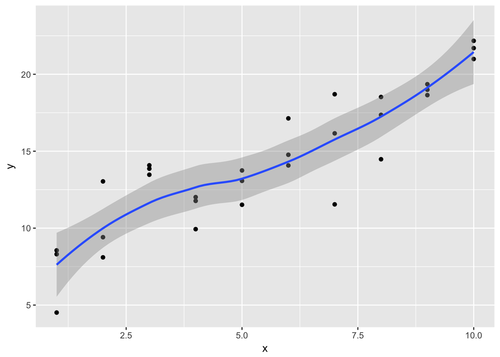

```r
ggplot (data=sim4a, aes(x=x, y=y)) +
  geom_point()+ geom_smooth()
```

```r
sim5a <- tibble(
x = rep(1:10, each = 3),
y = x * 1.5 + 6 + rt(length(x), df = 2))


uni_mod5 <- lm(y~x, data=sim5a)
tidy(uni_mod5)
```

```
##          term estimate std.error statistic      p.value
## 1 (Intercept) 6.874653  1.583872  4.340410 1.676802e-04
## 2           x 1.490600  0.255264  5.839443 2.821387e-06
```

```r
glance(uni_mod5)
```

```
##   r.squared adj.r.squared    sigma statistic      p.value df    logLik
## 1 0.5491078     0.5330045 4.015848   34.0991 2.821387e-06  2 -83.24072
##        AIC     BIC deviance df.residual
## 1 172.4814 176.685  451.557          28
```

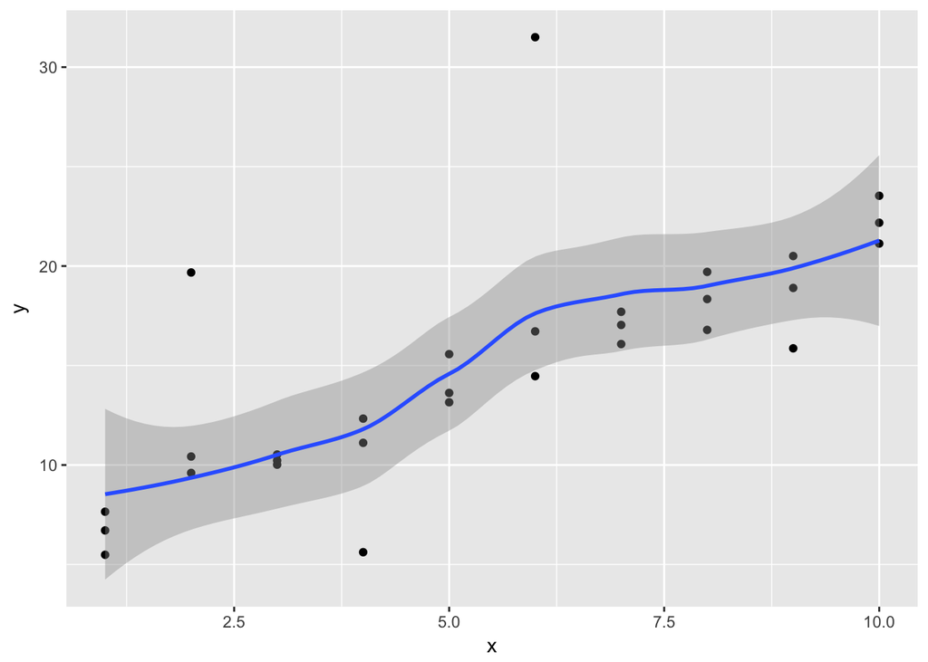

```r
ggplot (data=sim5a, aes(x=x, y=y)) +
  geom_point()+ geom_smooth()
```